# Seaborn - Visualizar relaciones estadísticas

```python
import numpy as np
import pandas as pd
import matplotlib.pyplot as plt
import seaborn as sb
```

```python
titanic = sb.load_dataset("titanic")
titanic.head(5)
```

|  | survived | pclass | sex | age | sibsp | parch | fare | embarked | class | who | adult_male | deck | embark_town | alive | alone |
| --- | --- | --- | --- | --- | --- | --- | --- | --- | --- | --- | --- | --- | --- | --- | --- |
| 0 | 0 | 3 | male | 22.0 | 1 | 0 | 7.2500 | S | Third | man | True | NaN | Southampton | no | False |
| 1 | 1 | 1 | female | 38.0 | 1 | 0 | 71.2833 | C | First | woman | False | C | Cherbourg | yes | False |
| 2 | 1 | 3 | female | 26.0 | 0 | 0 | 7.9250 | S | Third | woman | False | NaN | Southampton | yes | True |
| 3 | 1 | 1 | female | 35.0 | 1 | 0 | 53.1000 | S | First | woman | False | C | Southampton | yes | False |
| 4 | 0 | 3 | male | 35.0 | 0 | 0 | 8.0500 | S | Third | man | True | NaN | Southampton | no | True |

**Diagramas de dispersión categóricos**

Relación entre la tarifa que pagó cada viajero respecto a la clase en la que viajaba. Además, se hace distinción de si eran hombres o mujeres.

Algunos de los parámetros que podemos usar para completar el plot serían:

- hue: para crear una leyenda.
- jitter: **True** para controlar la magnitud de la fluctuación o **False** para desactivarlo.
- kind="swarm" : ajusta los puntos a lo largo del eje categórico mediante un algoritmo que evita que se superpongan. Puede proporcionar una mejor representación de la distribución de observaciones, aunque solo funciona bien para conjuntos de datos relativamente pequeños.
- El orden de las etiquetas se puede cambiar usando order= ["etiqueta 1", "etiqueta 2"]

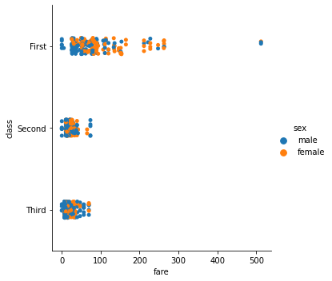

```python
sb.catplot(x="fare", y="class", jitter=True, hue="sex", data=titanic)
```

**Distribuciones de observaciones dentro de categorías**

A medida que aumenta el tamaño del conjunto de datos, los diagramas de dispersión categóricos se vuelven limitados en la información que pueden proporcionar sobre la distribución de valores dentro de cada categoría. Cuando esto sucede, existen varios enfoques para resumir la información de distribución de manera que faciliten las comparaciones entre los niveles de categoría.

**Boxplots**

Este tipo de gráfico muestra los valores de los tres cuartiles de la distribución junto con los valores extremos.

- Al añadir kind="box" podemos visulizar el boxplot.
- Cuando añadimos una leyenda con hue="sex", el cuadro para cada nivel de la variable semántica se mueve a lo largo del eje categórico para que no se superpongan. Este comportamiento se llama "dodging" (esquivar) y está activado de forma predeterminada porque se supone que la variable semántica está anidada dentro de la variable categórica principal. Si ese no es el caso, se puede desactivar la evasión con dodge=False.

`boxplot()`

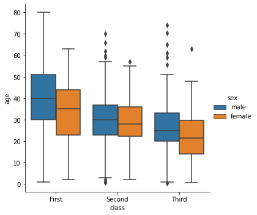

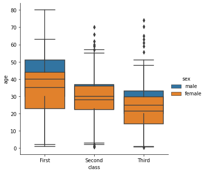

```python
#Usando catplot + kind = "box"
sb.catplot(x="class", y="age", kind="box", hue="sex", data=titanic)

sb.catplot(x="class", y="age", kind="box", hue="sex", dodge=False, data=titanic)
```

**Boxenplot**

Dibuja una gráfica que es similar a una gráfica de caja pero optimizada para mostrar más información sobre la forma de la distribución. Es más adecuado para conjuntos de datos más grandes.

`boxenplot()`

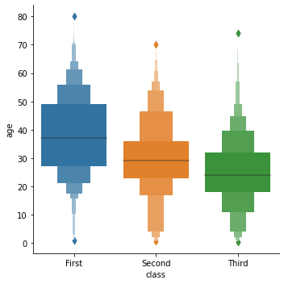

```python
#Usando catplot + kind = "boxen"
sb.catplot(x="class", y="age", kind="boxen", data=titanic)
```

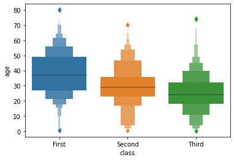

```python
#Usando boxenplot()
sb.boxenplot(x="class", y="age", data=titanic)
```

**Violenplot**

Combina un diagrama de caja con el procedimiento de estimación de la densidad del kernel. Este enfoque utiliza la estimación de la densidad del kernel para proporcionar una descripción más completa de la distribución de valores. Además, los valores de cuartiles y bigotes del diagrama de caja se muestran dentro del violín. La desventaja es que, debido a que la trama de violín usa un KDE, hay algunos otros parámetros que pueden necesitar ajustes, lo que agrega cierta complejidad en relación con la gráfica de caja sencilla.

Usando split = True también es posible "dividir" los violines cuando el parámetro de hue tiene solo dos niveles, lo que puede permitir un uso más eficiente del espacio.

Finalmente, hay varias opciones para la trama que se dibuja en el interior de los violines, incluidas las formas de mostrar cada observación individual en lugar de los valores de resumen de la gráfica de caja. Para esto usamos inner="stick".

`violenplot()`

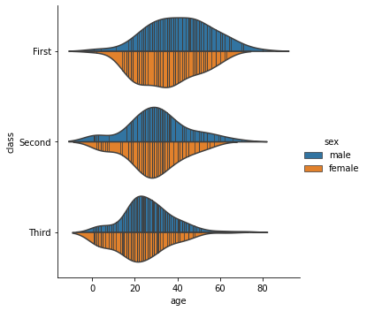

```python
sb.catplot(x="age", y="class", kind="violin", hue="sex", split=True, inner="stick", data=titanic)
```

**Estimación estadística dentro de categorías**

Para otras aplicaciones, en lugar de mostrar la distribución dentro de cada categoría, es posible que desee mostrar una estimación de la tendencia central de los valores. Seaborn tiene dos formas principales de mostrar esta información. Es importante destacar que la API básica para estas funciones es idéntica a la de las mencionadas anteriormente.

**Bar plots**

En seaborn, la función `barplot ()` opera en un conjunto de datos completo y aplica una función para obtener la estimación (tomando la media por defecto). Cuando hay varias observaciones en cada categoría, también usa bootstrapping para calcular un intervalo de confianza alrededor de la estimación, que se traza usando barras de error:

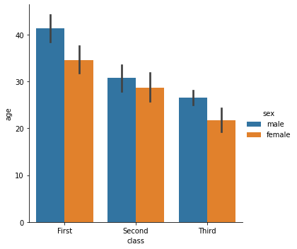

```python
sb.catplot(x="class", y="age", hue="sex", kind="bar", data=titanic)
```

Un caso especial para el diagrama de barras es cuando desea mostrar el número de observaciones en cada categoría en lugar de calcular una estadística para una segunda variable. Esto es similar a un histograma sobre una variable categórica, en lugar de cuantitativa. En seaborn, es fácil hacerlo con la función `countplot ()`:

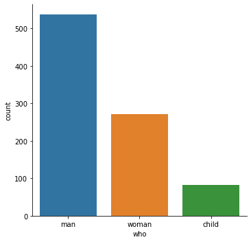

```python
#Usando catplot + kind = count
sb.catplot(x="who", kind="count", data=titanic)
```

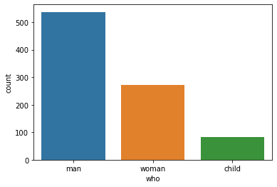

```python
#Usado directamente countplot()
sb.countplot(x="who", data=titanic)
```

Tanto `barplot ()` como `countplot ()` se pueden invocar con todas las opciones discutidas anteriormente, junto con otras que se muestran en la documentación detallada de cada función:

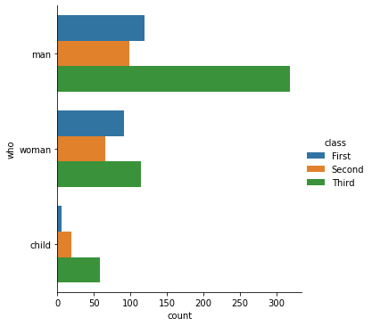

```python
sb.catplot(y="who", hue="class", kind="count", data=titanic)
```

**Point plots**

La función `pointplot ()` ofrece un estilo alternativo para visualizar la misma información. Esta función también codifica el valor de la estimación con la altura en el otro eje, pero en lugar de mostrar una barra completa, traza la estimación puntual y el intervalo de confianza. Además, `pointplot ()` conecta puntos de la misma categoría de tono. Esto hace que sea fácil ver cómo la relación principal está cambiando en función de la semántica de tono.

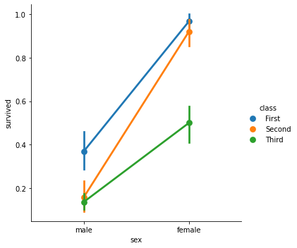

```python
#Usando catplot + kind = point
sb.catplot(x="sex", y="survived", kind="point", hue="class", data=titanic)
```

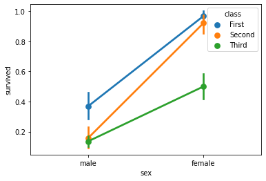

```python
#Usando pointplot()
sb.pointplot(x="sex", y="survived", hue="class", data=titanic)
```

Si bien las funciones categóricas carecen de la semántica de estilo de las funciones relacionales, aún puede ser una buena idea variar el marcador y / o el estilo de línea junto con el tono para hacer que las figuras sean lo más accesibles y se reproduzcan bien en blanco y negro.

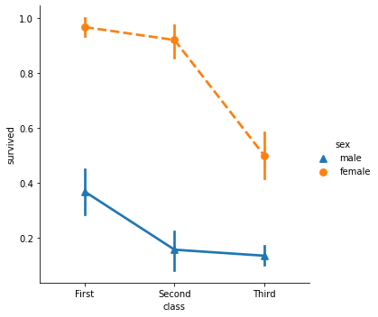

```python
#Usando catplot + kind = point
sb.catplot(x="class", y="survived", hue="sex", markers=["^", "o"], linestyles=["-", "--"], kind="point", data=titanic)
```

**Plotting “wide-form” data**

Si bien se prefiere el uso de datos de "formato largo" o "ordenados", estas funciones también se pueden aplicar a datos de "formato amplio" en una variedad de formatos, incluidos Pandas DataFrames o matrices numpy bidimensionales. Estos objetos deben pasarse directamente al parámetro de datos:

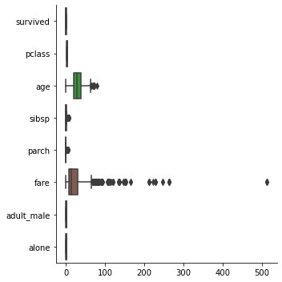

```python
sb.catplot(data=titanic, orient="h", kind="box")
```

Además, las funciones a nivel de ejes aceptan vectores de Pandas u objetos numpy en lugar de variables en un `DataFrame`:

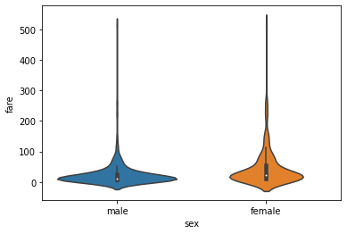

```python
sb.violinplot(x=titanic.sex, y=titanic.fare)
```

Es posible modificar el tamaño y la forma de los gráficos configurándolo con los comandos de matplotlib:

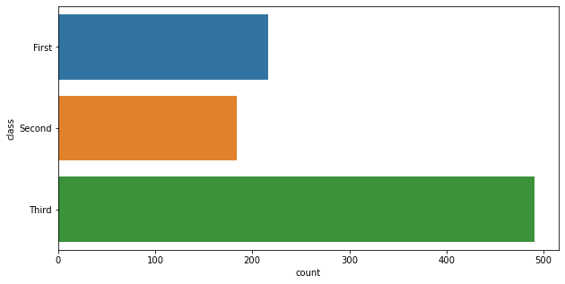

```python
f, ax = plt.subplots(figsize=(10, 5))
sb.countplot(y="class", data=titanic)
```

**Showing multiple relationships with facets**

`catplot ()` se basa en FacetGrid, lo que significa que es fácil agregar variables de facetado para visualizar relaciones de dimensiones superiores:

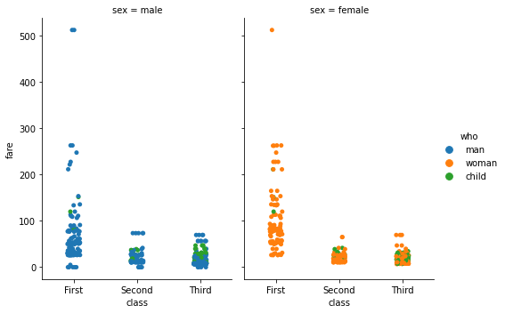

```python
sb.catplot(x="class", y="fare", hue="who", col="sex", aspect=.7, jitter=True, data=titanic)
```